# Homework 4

**Goal**

Practice interaction terms and logistic regression.

**Directions**

- Review the “General homework directions” on Moodle.
- At the top of your homework Rmd, load the following packages (inside a code chunk!):

  ```r
  library(ggplot2)
  library(dplyr)
  ```

**Exercises**

0. **Recommended but optional interaction practice**  
   Allen, Blascovich, Tomaka, and Kelsey (1991) asked a sample of 45 people to perform a stressful task: count backwards by 13’s and 17’s in front of the experimenter while either alone, in the presence of a friend, or in the presence of their pet. To assess stress levels, the researchers recorded the subjects’ mean and maximum heart rates during the experiment:

   ```r
   ps <- read.csv("https://www.macalester.edu/~ajohns24/data/PetStress.csv")
   ```

   | Variable | Meaning |
   | --- | --- |
   | `MaxHeartRate` | maximum observed heartrate in beats per minute (bpm) |
   | `MeanHeartRate` | average heartrate (bpm) |
   | `Condition` | `C`=control (alone),`F`=friend, `P`=pet |

   1. Construct and summarize a visualization of the relationship between `MaxHeartRate` (the response variable) by `MeanHeartRate` and `Condition`. Include a representation of the trend using `geom_smooth(method = "lm", se = FALSE)`.
   2. Consider the two models below. In the context of this study, explain the difference in the assumptions these models make about the relationships between the model variables.

      ```r
      stress_model_1 <- lm(MaxHeartRate ~ MeanHeartRate + Condition, ps)
      stress_model_2 <- lm(MaxHeartRate ~ MeanHeartRate * Condition, ps)
      ```

   3. Focus on `stress_model_2`. Use this model to construct an equation that captures the relationship between `MaxHeartRate` and `MeanHeartRate` for the pet group `P`. Be sure to write this in the form `MaxHeartRate = a + b MeanHeartRate` where you specify a and b.
   4. Interpret the `MeanHeartRate:ConditionP` coefficient in `stress_model_2` (0.405). Do so in the context of this study.
   5. Which model do you think is more appropriate, `stress_model_1` or `stress_model_2`? Support your argument with evidence from the plot as well as numerical evidence from the `stress_model_2` coefficients. NOTE: We’ll explore a more rigorous way to address such questions later in the semester!
1. **Cars**  
   Consider the `cars` data which contains the sales price and other information for used Ford cars in St Paul and Dallas. To begin, we can model the price of a car by its mileage and age (in years) *without* an interaction:

   ```r
   cars <- read.csv("http://www.macalester.edu/~ajohns24/data/FordsSub.csv")
   car_model_1 <- lm(Price ~ Mileage + Age, cars)
   summary(car_model_1)$coefficients
   ```

   ```
   ##                  Estimate   Std. Error   t value      Pr(>|t|)
   ## (Intercept)  1.581683e+04 2.914668e+02 54.266314 4.188908e-137
   ## Mileage     -6.888903e-02 7.187744e-03 -9.584234  1.220109e-18
   ## Age         -4.809437e+02 8.168277e+01 -5.887946  1.304907e-08
   ```

   The corresponding model formula corresponds to the plane shown below:

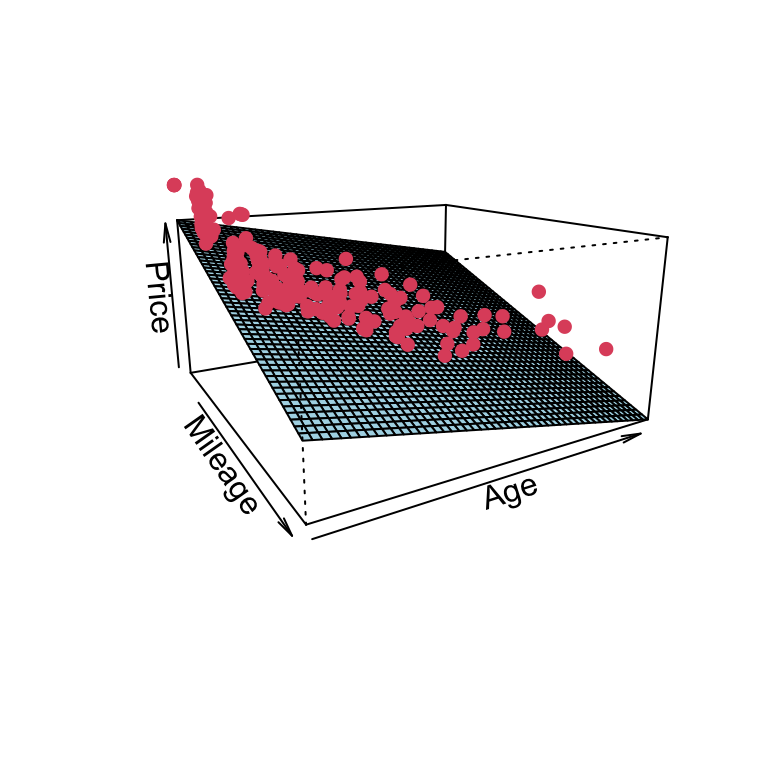

   By not including an interaction term, *the above model assumed that the association between price and mileage does not differ by the age of the car*. However, this assumption appears to be false. Instead, consider a model that includes an **interaction** between mileage and age:

   ```r
   car_model_2 <- lm(Price ~ Age * Mileage, cars)
   summary(car_model_2)$coefficients
   ```

   ```
   ##                  Estimate   Std. Error   t value      Pr(>|t|)
   ## (Intercept)  1.895467e+04 3.250928e+02  58.30543 1.061880e-143
   ## Age         -1.460909e+03 9.680060e+01 -15.09194  1.223559e-36
   ## Mileage     -1.219915e-01 6.793278e-03 -17.95768  2.776720e-46
   ## Age:Mileage  1.159252e-02 8.768120e-04  13.22122  2.405595e-30
   ```

   `car_model_2` produces the following model formula:

   `Price = 18950 - 1461*Age - 0.122*Mileage + 0.012 Age*Mileage`

   Plotted below, this looks pretty good!

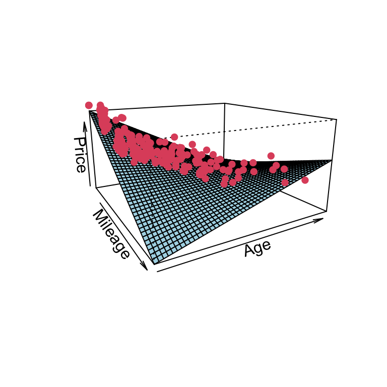

   1. Interpret the intercept coefficient, 18950. (This actually makes sense in this model!)
   2. Use `car_model_2` to predict the price of a 5 year old car that has 10,000 miles on it.
2. **Car interactions**

   By including an interaction term, `car_model_2` assumes that the association between price and mileage may differ depending on the age of the car. Let’s explore what this means in practice.
   1. Use `car_model_2` to construct formulas for the relationships between price and mileage for cars of different ages. Each of these should be of the form `Price = a + b Mileage` where you specify `a` and `b`. The first one is done for you. Complete the others using a similar technique.
      - **1 year old cars**
        $$\begin{split}
        \text{Price }
        & = 18950 - 1461*1 - 0.122 * \text{ Mileage} + 0.012 * 1 * \text{ Mileage} \\
        & = (18950 - 1461*1) + (-0.122 + 0.012*1) \text{ Mileage} \\
        & = 17489 - 0.11 \text{ Mileage} \\
        \end{split}$$
      - **5 year old cars**
      - **10 year old cars**

      These 3 lines are (roughly) captured in the plot below:

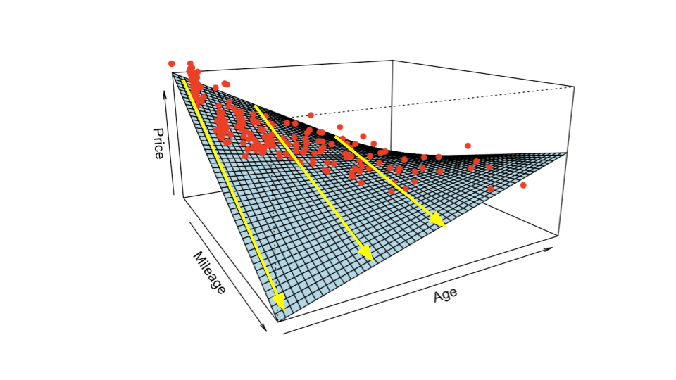

   2. Notice that the intercepts of these 3 models (ages 1, 5, 10) differ. Which of the following options is the best interpretation of these differences?
      - As the age of a car increases, the negative “impact” of mileage on price lessens.
      - As the age of a car increases, the negative “impact” of mileage on price becomes greater.
      - For cars with 0 mileage, average price increases as age increases.
      - For cars with 0 mileage, average price decreases as age increases.
   3. As seen in the plot and equations in part a, the slopes of these 3 models also differ! Which of the following options is the best interpretation of these differences?
      - As the age of a car increases, the negative “impact” of mileage on price lessens.
      - As the age of a car increases, the negative “impact” of mileage on price becomes greater.
      - For cars with 0 mileage, average price increases as age increases.
      - For cars with 0 mileage, average price decreases as age increases.
   4. In light of your work above, explain what the positive sign on the interaction coefficient indicates about the interaction between the mileage and age of a car.
3. **Politics**  
   In 2002 John McCain and John Kerry proposed new auto standards that would have forced manufacturers to increase fuel economy. Carl Levin proposed an amendment to the proposal that would *delay* any required increase in fuel economy. Hence a YES vote on the Levin amendment was good news for manufacturers. Senators also received contributions from auto manufacturers in 2002. This begs the questions: Who received the most auto contributions? Did it differ by political affiliation? How, if at all, were senators’ votes tied to their political affiliations and received auto contributions? In order to answer these questions, we’ll use the data set `senators`:

   ```r
   senators <- read.csv("http://www.macalester.edu/~ajohns24/data/Senate.csv")
   ```

   The `senators` data contains the following measurements on each senator:

   | Variable | Description |
   | --- | --- |
   | `Vote` | 1 (voted YES) or 0 (voted NO) |
   | `AutoCont` | dollars received from auto manufacturers |
   | `Party` | `D` (Democrat) or `R` (Republican) |
   | others | other variables indicate the senators’ names & states |

   1. There are 100 senators, 2 from each state. Using `dplyr()` functions, find the following summary statistics:
      - the number of 2002 senators that were Democrats
      - the number of senators that voted for the amendment
   2. Construct and comment on a *univariate* visualization of the received contributions (`AutoCont`).
   3. There’s a clear outlier that received *a lot* of money from auto manufacturers. Use `dplyr` code (don’t simply scan the data by eye) to identify the senator, and the state they represent. **Extra:** IF you’re familiar with the auto industry, comment on why this state affiliation might not surprise us.
   4. Create `senators_sub`, a subset of the data that does not include this outlier. Confirm that the properties of your `senators_sub` data set match those below. **IMPORTANT: Use the `senators_sub` data for the remainder of the homework.**

      ```r
      dim(senators_sub)
      ```

      ```
      ## [1] 99  6
      ```

      ```r
      senators_sub %>%
        summarize(mean(AutoCont))
      ```

      ```
      ##   mean(AutoCont)
      ## 1       12599.77
      ```

4. **Contributions vs party affiliation**  
   Let’s turn our attention to the relationship between the money senators received from auto manufacturers and their party affiliations.
   1. Construct and interpret a visualization of the relationship between `AutoCont` and `Party`. (Again, don’t forget to use `senators_sub`!!!!)
   2. Calculate the average `AutoCont` received by each party.
   3. Construct a model of `AutoCont` by `Party`. Include a model summary table.
   4. Interpret the `PartyR` coefficient.
5. **Votes vs party affiliation**  
   More importantly, we’re interested in modeling senators’ *votes*. *Don’t forget to use the `senators_sub` data in this analysis!*
   1. Construct and interpret a visualization of the relationship between senators’ votes, their party affiliations, *and* the amount of money they received from auto manufacturers. NOTE: Use `factor(Vote)` instead of `Vote` to treat 0/1 as categories, not numbers.
   2. Construct a model of `Vote` by `AutoCont` and `Party` *without* an interaction. Report a model summary table.
   3. By leaving an interaction term out of the model, what are we assuming? (Don’t just give the definition of interaction. Rather, explain what this means in the context of this analysis.)
6. **Interpreting the model**
   1. Let $p$ be the probability of a “yes” vote.
      - Write down the model equation of $p$ for Democrats.
      - Write down the model equation of $p$ for Republicans.
      - Use the following code to visualize the model (approximately):

      ```r
      ggplot(senators_sub, aes(x = AutoCont, y = Vote, color = Party)) +
          geom_smooth(method = "glm", method.args = list(family = "binomial"), se = FALSE, fullrange = TRUE)
      ```

   2. Interpret each of the `Intercept`, `AutoCont`, and `PartyR` coefficients in a meaningful way (in the context of the analysis and NOT on a log scale!). Don’t forget to note which variables you’re “controlling for” in these interpretations.
   3. For each of the following senators, calculate the probability that they’d vote “yes” for the pro-auto manufacturer amendment. You must show work and do the calculations from scratch, though you can check your work with `predict()`.
      - A Republican that received $1,000 from auto manufacturers.
      - A Democrat that received $1,000 from auto manufacturers.
      - A Republican that received $20,000 from auto manufacturers.
      - A Democrat that received $20,000 from auto manufacturers.
   4. Summarize your observations. What are the main take-home messages from this analysis? What was the relationship between votes, contributions, and party affiliation? **NOTE**: Had we used data for a vote on a different issue, we might see a different relationship between which party received the most money and how they voted!
   5. Explain why we can’t use this model to establish a cause-and-effect between money and votes (eg: that more money *causes* a senator to vote a certain way).

## Optional extra exercises: The Macalester Paradox

In this section, you will explore the Macalester natural gas data (described below). The exercises are more open-ended in nature. It’s important to practice and build up confidence in such settings. In answering these questions, consider the Macalester administration to be your audience. That is, describe your analysis in a contextually meaningful way with as little statistics jargon as possible.

`https://www.macalester.edu/~ajohns24/data/MacNaturalGas.csv`

Included are the following variables:

| variable | meaning |
| --- | --- |
| `therms` | a measure of energy use (the more energy used, the larger the `therms`) |
| `hdd` | “monthly heating degree days” is a measure of the amount of heating that the houses needed that month given the outside temperatures |
| `address` | location (`a`, `b`, `c`) |
| `renovated` | whether the location had already been renovated/insulated or not (`yes`, `no`) |
| `month` | from `1` (January) to `12` (December) |

**NOTE**

Because the houses were not fully instrumented, we only have information about the outside weather as measured by heating degree days (hdd). A quick peak confirms that high hdd reflects cold temperatures (cold temps require more heating) and that low hdd reflects warm temperatures (warm temps don’t require heating):

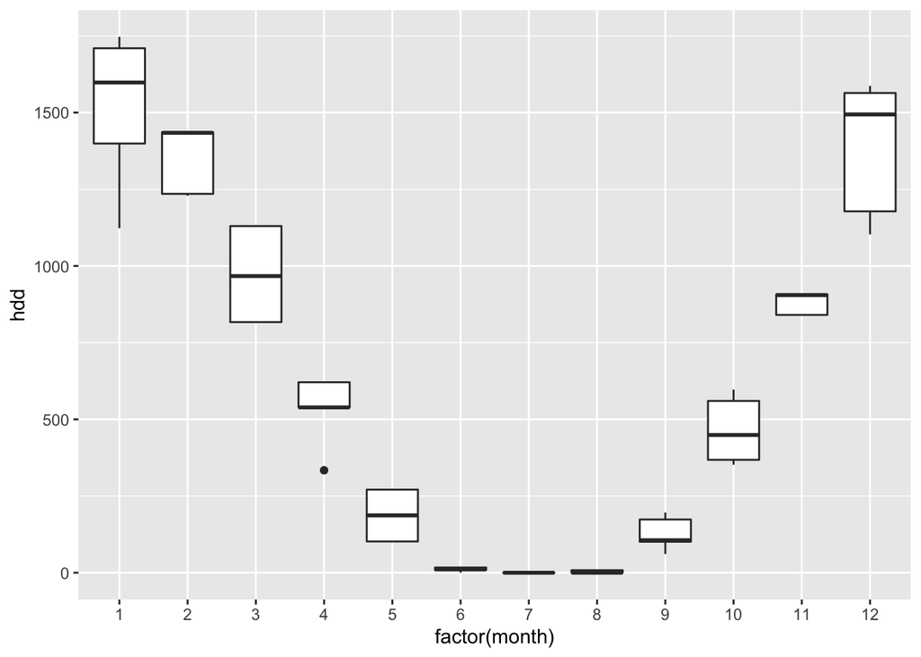

7. **An analysis**  
   The administration’s main question is whether or not the renovation paid off. That is, did the renovations result in lower energy usage? Analyze the data and present your findings to the administration. They are busy people, so keep your total discussion to 6 sentences or fewer. Further, make sure that your discussion and analysis incorporate the following pieces:
   - One visualization and one model that summarize the bivariate relationship between `therms` and `renovated`.
   - A second visualization and model that provide a more detailed look into this relationship (and that reveal the potentially misleading nature of the bivariate model). Keep this second model simple: incorporate only 1 additional predictor and do *not* include an interaction.
   - An *explanation* of the Simpson’s paradox your analysis has revealed with graphical evidence that supports your argument. For example, in the SAT example we explained that higher education funding doesn’t result in low SAT scores. Rather, states with higher education funding tend to have more students that take the SAT and that when more students take the SAT the average score tends to be smaller.
   - A final conclusion: did or did not the renovations result in energy savings?